# Writing Assignment

Leave This Blank

Last compiled: Feb 11, 2017

## Directions

Recreate this document exactly using [R Markdown](http://rmarkdown.rstudio.com/). A great reference for creating technical documents with R Markdown is [*bookdown: Authoring Books and Technical Documents with R Markdown*](https://bookdown.org/yihui/bookdown/). Your YAML should look similar to:

```
---
title: "Writing Assignment"
author: "Leave This Blank"
bibliography: [packages.bib, ISLR.bib]
output:
    bookdown::html_document2
date: 'Last compiled: `r format(Sys.time(), "%b %d, %Y")`'
---
```

# 1 From page 62 of [ISLR](http://www-bcf.usc.edu/~gareth/ISL/ISLR%20Sixth%20Printing.pdf) (James et al. 2013)

Let $\hat{y}_i = \hat{\beta}_0 + \hat{\beta}_1x_i$ be the prediction for $Y$ based on the $i^{\text{th}}$ value of $X$. Then $e_i = y_i - \hat{y}_i$ represents the $i^{\text{th}}$ *residual*—this is the difference between the $i^{\text{th}}$ observed response and the $i^{\text{th}}$ response value that is predicted by our linear model. We define the *residual sum of squares* (RSS) as

$$\begin{equation*}
\mathrm{RSS} = e_1^2 + e_2^2 + \cdots + e_n^2.
\end{equation*}$$

or equivalently as

$$\begin{equation}
\mathrm{RSS} = (y_1 - \hat{\beta}_0 - \hat{\beta}_1x_1 )^2 + (y_2 - \hat{\beta}_0 - \hat{\beta}_1x_2 )^2 + \cdots + (y_n - \hat{\beta}_0 - \hat{\beta}_1x_n )^2
\tag{1.1}
\end{equation}$$

The least squares approach chooses $\hat{\beta}_0$ and $\hat{\beta}_1$ to minimize the RSS. Using some calculus,one can show that the minimizers are

$$\begin{equation}
\begin{split}
\hat{\beta}_1 &= \frac{\sum_{i=1}^n(x_i - \bar{x})(y_i - \bar{y}) }{\sum_{i=1}^n (x_i - \bar{x})^2},\\
\hat{\beta}_0 &= \bar{y} - \hat{\beta}_1\bar{x},\\
\end{split}
\tag{1.2}
\end{equation}$$

where $\bar{y} \equiv \tfrac{1}{n}\sum_{i=1}^n y_i$ and $\bar{x} \equiv \tfrac{1}{n}\sum_{i=1}^n x_i$ are the sample means.

# 2 From page 63 of [ISLR](http://www-bcf.usc.edu/~gareth/ISL/ISLR%20Sixth%20Printing.pdf) (James et al. 2013)

Recall that we assume that the *true* relationship between $X$ and $Y$ takes the form $Y = f(X) + \epsilon$ for some unknown function $f$, where $\epsilon$ is a mean-zero random error term. If $f$ is to be approximated by a linear function, then we write this relationship as

$$\begin{equation}
Y = \beta_0 + \beta_1 + \epsilon
\tag{2.1}
\end{equation}$$

Here $\beta_0$ is the intercept term—that is, the expected values of $Y$ when $X = 0$, and $\beta_1$ is the slope—the average increase in $Y$ associated with a one-unit increase in $X$. The error term is a catch-all for what we miss with this simple model: the true relationship is probably not linear, there may be other variables that cause variation in $Y$, and there may be measurement error. We typically assume that the error term is independent of $X$.

# 3 From page 143 of [ISLR](http://www-bcf.usc.edu/~gareth/ISL/ISLR%20Sixth%20Printing.pdf) (James et al. 2013)

To indicate that a $p$-dimensional random variable $X$ has a multivariate Gaussian distribution, we write $X \sim N(\mu, \mathbf{\Sigma})$. Here $E(X) = \mu$ is the mean of $X$ (a vector with $p$ components), and $\mathrm{Cov}(X) = \mathbf{\Sigma}$ is the $p \times p$ covariance matrix of $X$. Formally, the multivariate Gaussian density is defined as

$$\begin{equation}
f(x) = \frac{1}{(2\pi)^{p/2}| \mathbf{\Sigma}|^{1/2}} \text{exp} \left(-\frac{1}{2}(x - \mu)^T \mathbf{\Sigma}^{-1} (x - \mu) \right)
\tag{3.1}
\end{equation}$$

In the case of $p > 1$ predictors, the LDA classifier assumes that the observations in the $k^{\text{th}}$ class are drawn from a multivariate Gaussian distribution $N(\mu_k, \mathbf{\Sigma})$, where $\mu_k$ is a class-specific mean vector, and $\mathbf{\Sigma}$ is the covariance matrix that is common to all $K$ classes. Plugging the density function for the $k^{\text{th}}$ class, $f_{k}(X = x)$, into (3.1) and performing a little bit of algebra reveals that the Bayes classifier assigns an observation $X=x$ to the class for which

$$\begin{equation}
\delta_k(x) = x^T \mathbf{\Sigma}^{-1} \mu_k -\frac{1}{2} \mu_k^T \mathbf{\Sigma}^{-1} \mu_k + \text{log}\pi_k
\tag{3.2}
\end{equation}$$

is the largest.

# 4 Inserting a graph

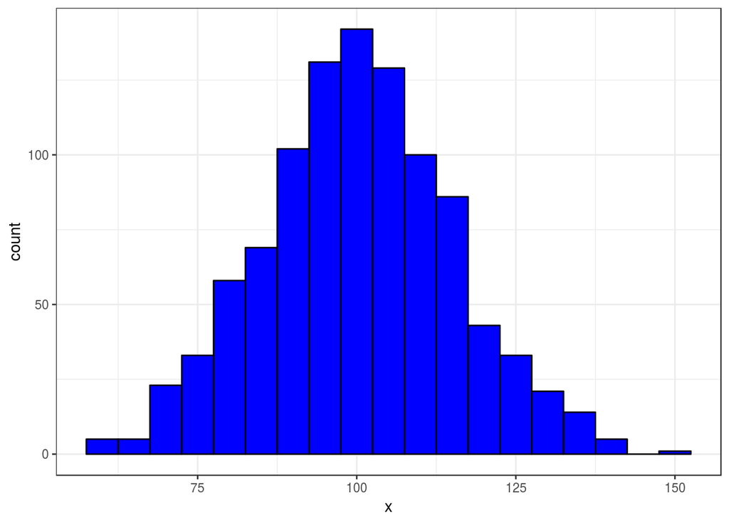

Figure 4.1: Your descriptive caption here

```r
set.seed(123)
x <- rnorm(1000, 100, 15)
DF <- data.frame(x = x)
library(ggplot2)
ggplot(data = DF, aes(x = x)) +
  geom_histogram(fill = "blue", color = "black", binwidth = 5) +
  theme_bw()
```

```r
xbar <- mean(x)
SD <- sd(x)
c(xbar, SD)
```

```
[1] 100.24192  14.87542
```

Figure 4.1 is unimodal with a mean of 100.2419 and a standard deviation of 14.8754.

# 5 Automagically Creating References

Review your last assignment to create a file named `packages.bib` to cite the `ggplot2` package used to create Figure 4.1. Figure 4.1 was created with `ggplot2` by Wickham and Chang (2016). This document specifies the output as `bookdown::html_document2`. The function `bookdown::html_document2` is from `bookdown` written by Xie (2016).

## References

James, Gareth, Daniela Witten, Trevor Hastie, and Robert Tibshirani. 2013. *An Introduction to Statistical Learning: With Applications in R*. 1st ed. 2013, Corr. 6th printing 2016 edition. New York: Springer.

Wickham, Hadley, and Winston Chang. 2016. *Ggplot2: Create Elegant Data Visualisations Using the Grammar of Graphics*. https://CRAN.R-project.org/package=ggplot2.

Xie, Yihui. 2016. *Bookdown: Authoring Books and Technical Documents with R Markdown*. https://CRAN.R-project.org/package=bookdown.